# EDAV project - Property Market Values

Andres

April 20, 2018

## Project Background

The Second Avenue Subway, a New York City Subway line that runs under Second Avenue on the East Side of Manhattan, has been proposed since 1920. The first phase of the line, consisting of three stations on the Upper East Side, started construction in 2007 and opened in 2017, ninety-seven years after the route was first proposed. Up until the 1960s, many distinct plans for the Second Avenue subway line were never carried out, though small segments were built in the 1970s. The complex reasons for these delays are why the line is sometimes called “the line that time forgot” (source: Wikipedia).

A brief summary of more important milestones is:

##### Phase 1 only:

2005: Voters passed a transportation bond issue on November 8, 2005, allowing for dedicated funding allocated for phase 1.  
2006: United States Department of Transportation (USDOT) agave $1.3 billion in federal funding for the phase 1, to be funded over a seven-year period. Preliminary engineering and a final tunnel design was completed.  
2007: Final Phase 1 construction started.  
2017: after several news about progress and delays, phase 1 finally opened on Jan 1st. This phase 1 consisting of the 96th Street, 86th Street, and 72nd Street stations and two miles (3.2 km) of tunnel, had a cost of $4.45 billion.

##### Phase 2 only:

2015: phase 2 was allocated $535 million in the MTA’s 2015-2019 Capital Plan for planning, design, environmental studies, and utility relocation.  
2016: In March, MTA began advertising Requests for Proposals (RFP) for three new contracts for phase 2. In April 2016, the MTA and the State of New York reached a deal to restore funding to Phase 2, with a total of $1.035 billion allocated. On May 24, 2017, the MTA Board increased funding for Phase 2 to $1.735 billion.  
2017: by August 2017, preliminary work on the line was underway, and the engineering firm AKRF was updating the environmental impact study for Phase 2.

##### Phases 3 and 4:

Phases 3 and 4 have no funding commitments yet.

The full length of the project and it’s phases and stations can be easily visualized in the following graph:

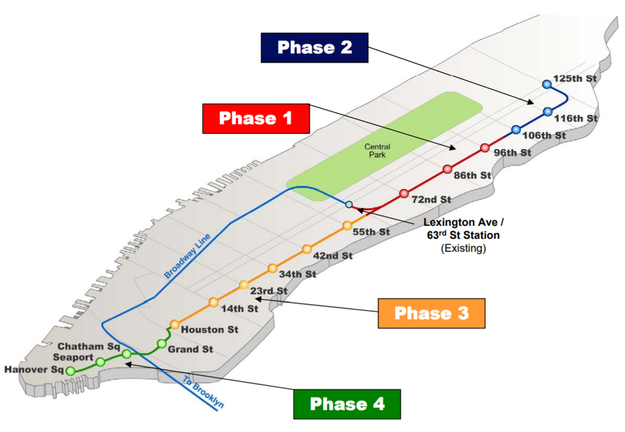

Source: http://www.apta.com/previousmc/multimodal/previous/2010/Presentations/Planning-for-the-Second-Avenue-Subway-From-Dream-to.pdf

## Analysis of Property Market Value

One of the analysis we decided to perform to answer our question, was to see how the 2nd Ave line project has affected the Market Value of property located in the project’s area of influence (basically, phase 1 and 2, because phase 3 and 4 have no funding commitments yet).

We got the market values dataset from The Department of Finance (DOF), which every year estimates the property’s market value for all New York City properties, comparing each property market value with recent sales in the neighborhood. The estimated market value is used by the DOF to determine the assessed value and then the City’s property tax rates are applied to the assessed value to calculate the property taxes for the next tax year.

The link to the webpage where we were able to find the data is: http://www1.nyc.gov/site/finance/taxes/property-assessments.page

There, we were able to find the tentative property assessment for fiscal year 2019 (with a total NYC property Market Value of about $1.258 trillion, an increase of $108.4 billion, or 9.4 percent from the 2018 Fiscal Year), as well as the final property assessments from 2018 fiscal year, back to 2009 fiscal year, one dataset for every year.

a Data Dictionary containing field codes and descriptions of the data sets can be found here: http://www1.nyc.gov/assets/finance/downloads/tar/tarfieldcodes.pdf

After downloading and extracting the zip files for the original datasets we read each dataset, take a look at it, read the corresponding Data Dictionary and inspect variables/column names.

Then we filtered Manhattan Zip codes that are within the area of influence of phase1 and phase 2 of the project (10065, 10021, 10075, 10028, 10128, 10029, 10035), selected relevant columns of our interest and added a column/variable named “Year”, to indicate the year when the market value assessment was produced (for the 2019 fiscal year, the data was produces in “Year” = 2018).

After following the above process for each year’s dataset, we combined year by year into a single dataset.

```r
library(tidyverse)
#install.packages('RODBC')
library(RODBC)

mdbConnect<-odbcConnectAccess("avroll_19.mdb")
property <- sqlFetch(mdbConnect,"avroll")
odbcClose(mdbConnect)
#head(property)
#colnames(property) #print variables / column names

property_upper_east <- property %>%
  filter(B==1 & ZIP %in% c(10065, 10021, 10075, 10028, 10128, 10029, 10035)) %>% select(BLOCK,LOT,BLDGCL,FULLVAL) %>%
    mutate(Year = 2018)
str(property_upper_east)
```

```
## 'data.frame':    28608 obs. of  5 variables:
##  $ BLOCK  : int  560 1111 1375 1375 1375 1375 1375 1375 1375 1375 ...
##  $ LOT    : int  7501 1 1 16 21 36 42 49 67 146 ...
##  $ BLDGCL : Factor w/ 214 levels "A0","A1","A2",..: 139 130 62 115 115 102 113 115 64 113 ...
##  $ FULLVAL: num  0.00 7.79e+09 2.42e+07 1.06e+08 1.47e+08 ...
##  $ Year   : num  2018 2018 2018 2018 2018 ...
```

```r
mdbConnect<-odbcConnectAccess("avroll_18.mdb")
new_property <- sqlFetch(mdbConnect,"avroll")
odbcClose(mdbConnect)
#head(new_property)
#colnames(new_property) #print variables / column names

new_property_upper_east <- new_property %>%
  filter(B==1 & ZIP %in% c(10065, 10021, 10075, 10028, 10128, 10029, 10035)) %>% select(BLOCK,LOT,BLDGCL,FULLVAL) %>%
    mutate(Year = 2017)
str(new_property_upper_east)
```

```
## 'data.frame':    28456 obs. of  5 variables:
##  $ BLOCK  : int  560 1111 1375 1375 1375 1375 1375 1375 1375 1375 ...
##  $ LOT    : int  7501 1 1 16 36 42 49 67 146 147 ...
##  $ BLDGCL : Factor w/ 214 levels "A0","A1","A2",..: 139 130 62 115 102 113 115 64 113 91 ...
##  $ FULLVAL: num  0.00 7.56e+09 2.40e+07 1.02e+08 3.69e+07 ...
##  $ Year   : num  2017 2017 2017 2017 2017 ...
```

```r
property_upper_east <- rbind.data.frame(new_property_upper_east, property_upper_east)
#str(property_upper_east)
#write.table(property_upper_east, file="property_upper_east.csv",sep=",",row.names=F)

mdbConnect<-odbcConnectAccess("avroll_17.mdb")
new_property <- sqlFetch(mdbConnect,"avroll")
odbcClose(mdbConnect)
#head(new_property)
#colnames(new_property) #print variables / column names

new_property_upper_east <- new_property %>%
  filter(B==1 & ZIP %in% c(10065, 10021, 10075, 10028, 10128, 10029, 10035)) %>% select(BLOCK,LOT,BLDGCL,FULLVAL) %>%
    mutate(Year = 2016)
str(new_property_upper_east)
```

```
## 'data.frame':    28156 obs. of  5 variables:
##  $ BLOCK  : int  560 1111 1375 1375 1375 1375 1375 1375 1375 1375 ...
##  $ LOT    : int  7501 1 1 16 36 42 49 67 146 147 ...
##  $ BLDGCL : Factor w/ 214 levels "A0","A1","A2",..: 139 130 62 115 102 113 115 64 113 91 ...
##  $ FULLVAL: num  0.00 7.34e+09 2.50e+07 9.16e+07 3.50e+07 ...
##  $ Year   : num  2016 2016 2016 2016 2016 ...
```

```r
property_upper_east <- rbind.data.frame(new_property_upper_east, property_upper_east)
#str(property_upper_east)
#write.table(property_upper_east, file="property_upper_east.csv",sep=",",row.names=F)

mdbConnect<-odbcConnectAccess("avroll_16.mdb")
new_property <- sqlFetch(mdbConnect,"avroll")
odbcClose(mdbConnect)
#head(new_property)
#colnames(new_property) #print variables / column names

new_property_upper_east <- new_property %>%
  filter(B==1 & ZIP %in% c(10065, 10021, 10075, 10028, 10128, 10029, 10035)) %>% select(BLOCK,LOT,BLDGCL,FULLVAL) %>%
    mutate(Year = 2015)
str(new_property_upper_east)
```

```
## 'data.frame':    27549 obs. of  5 variables:
##  $ BLOCK  : int  560 1111 1375 1375 1375 1375 1375 1375 1375 1375 ...
##  $ LOT    : int  7501 1 1 16 36 42 49 67 146 147 ...
##  $ BLDGCL : Factor w/ 212 levels "A0","A1","A2",..: 137 128 60 112 100 110 112 62 118 89 ...
##  $ FULLVAL: num  0.00 7.13e+09 2.24e+07 8.53e+07 3.31e+07 ...
##  $ Year   : num  2015 2015 2015 2015 2015 ...
```

```r
property_upper_east <- rbind.data.frame(new_property_upper_east, property_upper_east)
#str(property_upper_east)
#write.table(property_upper_east, file="property_upper_east.csv",sep=",",row.names=F)

mdbConnect<-odbcConnectAccess("avroll_15.mdb")
new_property <- sqlFetch(mdbConnect,"avroll")
odbcClose(mdbConnect)
#head(new_property)
#colnames(new_property) #print variables / column names

new_property_upper_east <- new_property %>%
  filter(B==1 & ZIP %in% c(10065, 10021, 10075, 10028, 10128, 10029, 10035)) %>% select(BLOCK,LOT,BLDGCL,FULLVAL) %>%
    mutate(Year = 2014)
str(new_property_upper_east)
```

```
## 'data.frame':    27548 obs. of  5 variables:
##  $ BLOCK  : int  560 1111 1375 1375 1375 1375 1375 1375 1375 1375 ...
##  $ LOT    : int  7501 1 1 16 36 37 42 49 67 146 ...
##  $ BLDGCL : Factor w/ 208 levels "A0","A1","A2",..: 132 123 60 107 95 31 89 107 62 113 ...
##  $ FULLVAL: num  0.00 6.92e+09 2.10e+07 7.77e+07 3.10e+07 ...
##  $ Year   : num  2014 2014 2014 2014 2014 ...
```

```r
property_upper_east <- rbind.data.frame(new_property_upper_east, property_upper_east)
#str(property_upper_east)
#write.table(property_upper_east, file="property_upper_east.csv",sep=",",row.names=F)

mdbConnect<-odbcConnectAccess("avroll_14.mdb")
new_property <- sqlFetch(mdbConnect,"avroll")
odbcClose(mdbConnect)
#head(new_property)
#colnames(new_property) #print variables / column names

new_property_upper_east <- new_property %>%
  filter(B==1 & ZIP %in% c(10065, 10021, 10075, 10028, 10128, 10029, 10035)) %>% select(BLOCK,LOT,BLDGCL,FULLVAL) %>%
    mutate(Year = 2013)
str(new_property_upper_east)
```

```
## 'data.frame':    27024 obs. of  5 variables:
##  $ BLOCK  : int  560 1111 1375 1375 1375 1375 1375 1375 1375 1375 ...
##  $ LOT    : int  7501 1 1 16 36 37 42 49 67 146 ...
##  $ BLDGCL : Factor w/ 208 levels "A0","A1","A2",..: 132 123 60 107 95 31 89 107 62 113 ...
##  $ FULLVAL: num  0.00 6.57e+09 1.83e+07 8.79e+07 2.87e+07 ...
##  $ Year   : num  2013 2013 2013 2013 2013 ...
```

```r
property_upper_east <- rbind.data.frame(new_property_upper_east, property_upper_east)
#str(property_upper_east)
#write.table(property_upper_east, file="property_upper_east.csv",sep=",",row.names=F)

mdbConnect<-odbcConnectAccess("avroll_13.mdb")
new_property <- sqlFetch(mdbConnect,"avroll")
odbcClose(mdbConnect)
#head(new_property)
#colnames(new_property) #print variables / column names

new_property_upper_east <- new_property %>%
  filter(B==1 & ZIP %in% c(10065, 10021, 10075, 10028, 10128, 10029, 10035)) %>% select(BLOCK,LOT,BLDGCL,FULLVAL) %>%
    mutate(Year = 2012)
str(new_property_upper_east)
```

```
## 'data.frame':    27011 obs. of  5 variables:
##  $ BLOCK  : int  560 1111 1375 1375 1375 1375 1375 1375 1375 1375 ...
##  $ LOT    : int  7501 1 1 16 36 37 42 49 67 146 ...
##  $ BLDGCL : Factor w/ 199 levels "A0","A1","A2",..: 132 123 60 107 95 31 89 107 62 113 ...
##  $ FULLVAL: num  0.00 6.57e+09 1.78e+07 8.62e+07 2.87e+07 ...
##  $ Year   : num  2012 2012 2012 2012 2012 ...
```

```r
property_upper_east <- rbind.data.frame(new_property_upper_east, property_upper_east)
#str(property_upper_east)
#write.table(property_upper_east, file="property_upper_east.csv",sep=",",row.names=F)

mdbConnect<-odbcConnectAccess("avroll_12.mdb")
new_property <- sqlFetch(mdbConnect,"avroll")
odbcClose(mdbConnect)
#head(new_property)
#colnames(new_property) #print variables / column names

new_property_upper_east <- new_property %>%
  filter(B==1 & ZIP %in% c(10065, 10021, 10075, 10028, 10128, 10029, 10035)) %>% select(BLOCK,LOT,BLDGCL,FULLVAL) %>%
    mutate(Year = 2011)
str(new_property_upper_east)
```

```
## 'data.frame':    26813 obs. of  5 variables:
##  $ BLOCK  : int  560 1111 1375 1375 1375 1375 1375 1375 1375 1375 ...
##  $ LOT    : int  7501 1 1 16 36 37 42 49 67 146 ...
##  $ BLDGCL : Factor w/ 199 levels "A0","A1","A2",..: 132 123 60 107 95 31 89 107 62 113 ...
##  $ FULLVAL: num  0.00 6.57e+09 1.72e+07 6.88e+07 2.87e+07 ...
##  $ Year   : num  2011 2011 2011 2011 2011 ...
```

```r
property_upper_east <- rbind.data.frame(new_property_upper_east, property_upper_east)
#str(property_upper_east)
#write.table(property_upper_east, file="property_upper_east.csv",sep=",",row.names=F)

mdbConnect<-odbcConnectAccess("avroll_11.mdb")
new_property <- sqlFetch(mdbConnect,"avroll")
odbcClose(mdbConnect)
#head(new_property)
#colnames(new_property) #print variables / column names

new_property_upper_east <- new_property %>%
  filter(B==1 & ZIP %in% c(10065, 10021, 10075, 10028, 10128, 10029, 10035)) %>% select(BLOCK,LOT,BLDGCL,FULLVAL) %>%
    mutate(Year = 2010)
str(new_property_upper_east)
```

```
## 'data.frame':    26746 obs. of  5 variables:
##  $ BLOCK  : int  560 1111 1375 1375 1375 1375 1375 1375 1375 1375 ...
##  $ LOT    : int  7501 1 1 16 36 37 42 49 67 146 ...
##  $ BLDGCL : Factor w/ 200 levels "A0","A1","A2",..: 133 124 61 108 96 31 90 108 63 114 ...
##  $ FULLVAL: num  0.00 6.15e+09 1.69e+07 5.15e+07 2.79e+07 4.07e+07 4.62e+06 1.74e+08 1.15e+08 4.33e+06 ...
##  $ Year   : num  2010 2010 2010 2010 2010 2010 2010 2010 2010 2010 ...
```

```r
property_upper_east <- rbind.data.frame(new_property_upper_east, property_upper_east)
#str(property_upper_east)
#write.table(property_upper_east, file="property_upper_east.csv",sep=",",row.names=F)

mdbConnect<-odbcConnectAccess("avroll_10.mdb")
new_property <- sqlFetch(mdbConnect,"avroll")
odbcClose(mdbConnect)
#head(new_property)
#colnames(new_property) #print variables / column names

new_property_upper_east <- new_property %>%
  filter(B==1 & ZIP %in% c(10065, 10021, 10075, 10028, 10128, 10029, 10035)) %>% select(BLOCK,LOT,BLDGCL,FULLVAL) %>%
    mutate(Year = 2009)
str(new_property_upper_east)
```

```
## 'data.frame':    26568 obs. of  5 variables:
##  $ BLOCK  : int  560 1111 1375 1375 1375 1375 1375 1375 1375 1375 ...
##  $ LOT    : int  7501 1 1 16 36 37 42 49 67 146 ...
##  $ BLDGCL : Factor w/ 199 levels "A0","A1","A2",..: 132 123 60 107 95 31 89 107 62 113 ...
##  $ FULLVAL: num  0.00 6.04e+09 1.75e+07 5.13e+07 2.66e+07 ...
##  $ Year   : num  2009 2009 2009 2009 2009 ...
```

```r
property_upper_east <- rbind.data.frame(new_property_upper_east, property_upper_east)
#str(property_upper_east)
#write.table(property_upper_east, file="property_upper_east.csv",sep=",",row.names=F)

mdbConnect<-odbcConnectAccess("avroll_09_class 1.mdb")
new_property <- sqlFetch(mdbConnect,"tc1")
odbcClose(mdbConnect)
#head(new_property)
#colnames(new_property) #print variables / column names

new_property_upper_east <- new_property %>%
  mutate(FULLVAL = NEW_FV_T) %>%
  filter(BORO==1 & ZIP %in% c(10065, 10021, 10075, 10028, 10128, 10029, 10035)) %>% select(BLOCK,LOT,BLDGCL,FULLVAL) %>%
    mutate(Year = 2008)
str(new_property_upper_east)
```

```
## 'data.frame':    1705 obs. of  5 variables:
##  $ BLOCK  : num  1376 1377 1377 1377 1377 ...
##  $ LOT    : num  64 42 46 63 64 65 8 27 28 29 ...
##  $ BLDGCL : Factor w/ 26 levels "A0","A1","A2",..: 15 5 8 11 13 13 5 8 5 5 ...
##  $ FULLVAL: num  20500000 7550000 37500000 14000000 11400000 16700000 14900000 9790000 9790000 9670000 ...
##  $ Year   : num  2008 2008 2008 2008 2008 ...
```

```r
property_upper_east <- rbind.data.frame(new_property_upper_east, property_upper_east)
#str(property_upper_east)
#write.table(property_upper_east, file="property_upper_east.csv",sep=",",row.names=F)

mdbConnect<-odbcConnectAccess("avroll_09_class 2,3,4.mdb")
new_property <- sqlFetch(mdbConnect,"tc234")
odbcClose(mdbConnect)
#head(new_property)
#colnames(new_property) #print variables / column names

new_property_upper_east <- new_property %>%
  mutate(FULLVAL = NEW_FV_T) %>%
  filter(BORO==1 & ZIP %in% c(10065, 10021, 10075, 10028, 10128, 10029, 10035)) %>% select(BLOCK,LOT,BLDGCL,FULLVAL) %>%
    mutate(Year = 2008)
str(new_property_upper_east)
```

```
## 'data.frame':    23149 obs. of  5 variables:
##  $ BLOCK  : num  560 1111 1375 1375 1375 ...
##  $ LOT    : num  7501 1 1 16 36 ...
##  $ BLDGCL : Factor w/ 172 levels "C1","C2","C3",..: 116 107 44 91 79 16 73 91 46 97 ...
##  $ FULLVAL: num  0.00 5.76e+09 1.80e+07 5.10e+07 2.58e+07 ...
##  $ Year   : num  2008 2008 2008 2008 2008 ...
```

```r
property_upper_east <- rbind.data.frame(new_property_upper_east, property_upper_east)
str(property_upper_east)
```

```
## 'data.frame':    299333 obs. of  5 variables:
##  $ BLOCK  : num  560 1111 1375 1375 1375 ...
##  $ LOT    : num  7501 1 1 16 36 ...
##  $ BLDGCL : Factor w/ 218 levels "C1","C2","C3",..: 116 107 44 91 79 16 73 91 46 97 ...
##  $ FULLVAL: num  0.00 5.76e+09 1.80e+07 5.10e+07 2.58e+07 ...
##  $ Year   : num  2008 2008 2008 2008 2008 ...
```

Next, we write a new file ‘property_upper_east.csv’ in the working directory, for future use whenever we need to read the data again, because reading the original files takes too long time:

```r
write.table(property_upper_east, file="property_upper_east.csv",sep=",",row.names=F)
```

### Analysis of Market Values for Phase 1

Now we add a column called “Distance” and use the block number to record the approximate distance (in blocks) from each property, to the 2nd Ave Line.

For this purpose, we used the Block number column/variable and the official tax map for the City of New York, which graphically shows the the block number, street names and other information in the map. The link where we were able to access the online Digital Tax Map is: http://gis.nyc.gov/taxmap/map.html

Using that info, we were able to generate the following map, where we could manually place the pre-existing Lexington-Fourth Avenue Line (green line), the phase 1 of the 2nd Ave project (yellow line) and the stations entrances, to visually determine the block numbers that are near the phase 1 of the 2nd Ave line and their distance (in blocks) to the Line:

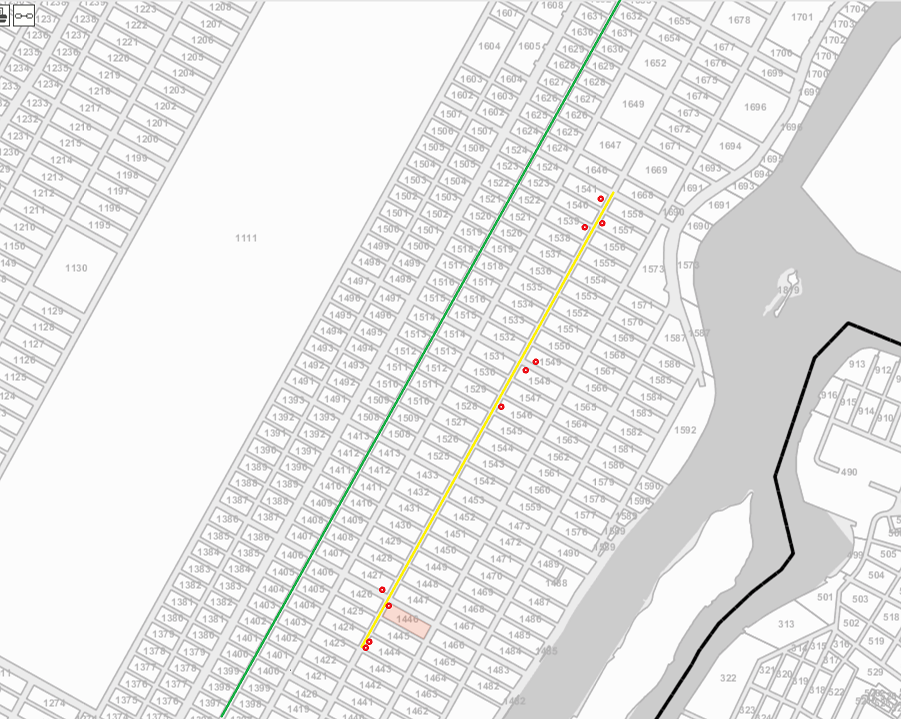

When determining the distances of the properties to the 2nd Ave line, we differentiated between properties to the left of the 2nd Ave Line and properties to the right of the Line, because we suspected that the influence of the 2nd Ave Line may be greater for properties to the right of the line than for properties to the left, due to the proximity of the pre-existing Lexington-Fourth Avenue green Line right to the left of the 2nd Ave Line project.

#### Properties on the left side of the 2nd Ave Line - Phase 1

For blocks to the left of the 2nd Ave Line, as we can see in the map above, we can determine 3 different categories:

1. block numbers that are within 1 block to the left;
2. block numbers that are within 2-3 blocks to the left; and
3. block numbers that are within 4-5 blocks to the left; from the 2nd Ave Line

Using the block numbers for each of the 3 categories detailed above, we can add a column called “Distance” and use the block number to record the approximate distance (in blocks) from each property to the left of the 2nd Ave Line - Phase 1:

```r
property_upper_east <- read.csv("property_upper_east.csv")
#head(property_upper_east)
data_phase1 <- property_upper_east %>%
  mutate(Distance = ifelse(BLOCK %in% c(1424:1427, 1529:1532,1539:1541,1423,1428:1433,
                                        1525:1528,1533:1538,1646),
                                 '1 block left from 2nd Ave line',
                          ifelse(BLOCK %in% c(1404:1407,1512:1515,1522:1524,1403,1408:1413,
                                              1508:1511,1516:1521,1624),
                                 '2-3 blocks left from 2nd Ave line',
                          ifelse(BLOCK %in% c(1384:1387,1495:1498,1505:1507,1383,1388:1393,
                                              1491:1494,1499:1504,1602),
                                 '4-5 blocks left from 2nd Ave line',
                                 'other'))))
#write.table(data_phase1, file="data_phase1-left.csv",sep=",",row.names=F)
```

Now we can visualize and compare the variation of Property Market Values over time, among the different categories detailed above.

For this purpose, we first summarize by Year and Distance, then we scale the data and create an index to visualize variation in market value over time with time series lines:

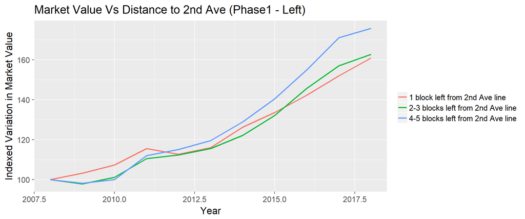

```r
#First, summarize by Year and Distance:
data_phase1 <- data_phase1 %>%
  group_by(Year, Distance) %>%
  summarise(Total = sum(FULLVAL))
#head(data_phase1)

#Now, scale the data and create an index to visualize variations over time, then plot:
data_phase1 <- data_phase1 %>% group_by(Distance) %>%
  #filter(Year >= 2001 & Year <= 2017) %>%
  filter(Distance != "other") %>%
  mutate(index = 100*Total/Total[1]) %>% ungroup()
#head(data_phase1)

#save results to be used for presentation purposes:
#write.table(data_phase1,file="Markt_Value-2nd-ave-line_phase1_left.csv",sep=",",row.names=F)

#Plot time series:
ggplot(data_phase1, aes(Year, index, color = Distance)) + geom_line(lwd = 1) +
    ggtitle("Market Value Vs Distance to 2nd Ave (Phase1 - Left)") +
    labs (x = "Year", y = "Indexed Variation in Market Value") +
    theme_grey(16) +
    theme(legend.title = element_blank())
```

**Conclusions:** From the graph above we think that it is inconclusive whether phase 1 of the 2nd Ave Line project is having an impact on the increase in Property Market Value for properties located in the vicinity to the left of the Line. On the contrary, we can see that properties located within 4-5 blocks left from the Line show a slightly higher increase than properties in other categories.

#### Properties on the right side of the 2nd Ave Line - Phase 1

For blocks to the right of the 2nd Ave Line, as we can see in the map previously shared above, there are just 3 blocks between the 2nd Ave Line and the East River, except for a small row of few blocks located four blocks from the Line (at the north end), so we established 3 different categories as follows:

1. block numbers that are within 1 block to the right;
2. block numbers that are within 2 blocks to the right; and
3. block numbers that are within 3-4 blocks to the right; from the 2nd Ave Line

Using the block numbers for each of those 3 categories, we followed the same procedure described above to analyze properties to the left, going back to the original data to add a column called “Distance” and using the block number to record the approximate distance (in blocks) from each property to the right of the 2nd Ave Line - phase 1:

```r
property_upper_east <- read.csv("property_upper_east.csv")
data_phase1 <- property_upper_east %>%
  mutate(Distance = ifelse(BLOCK %in% c(1444:1447,1546:1549,1556:1558,1443,1448:1453,
                                        1542:1545,1550:1555,1668),
                                 '1 block right from 2nd Ave Line',
                          ifelse(BLOCK %in% c(1464:1467,1563:1566,1573,1463,1468:1473,
                                              1559:1562,1567:1571,1690),
                                 '2 blocks right from line',
                          ifelse(BLOCK %in% c(1482:1484,1580:1583,1480,1485:1490,1576:1579,
                                              1584:1587,1590,1592,1589),
                                 '3-4 blocks right from 2nd Ave Line',
                                 'other'))))
```

Now we can visualize and compare the variation of Property Market Values over time, among the different categories detailed above, by following the same procedure described previously:

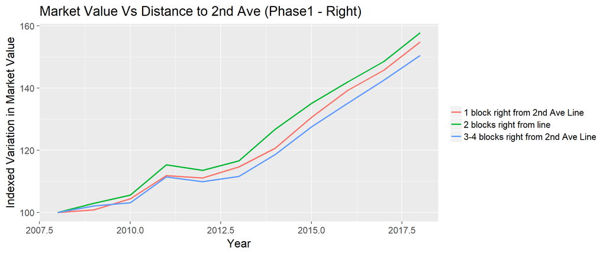

```r
#First, summarize by Year and Distance:
data_phase1 <- data_phase1 %>%
  group_by(Year, Distance) %>%
  summarise(Total = sum(FULLVAL))
#head(data_phase1)

#Now, scale the data and create an index to visualize variations over time, then plot:
data_phase1 <- data_phase1 %>% group_by(Distance) %>%
  #filter(Year >= 2001 & Year <= 2017) %>%
  filter(Distance != "other") %>%
  mutate(index = 100*Total/Total[1]) %>% ungroup()
#head(data_phase1)

#save results to be used for presentation purposes:
#write.table(data_phase1,file="Markt_Value-2nd-ave-line_phase1_left.csv",sep=",",row.names=F)

#Plot time series:
ggplot(data_phase1, aes(Year, index, color = Distance)) + geom_line(lwd = 1) +
    ggtitle("Market Value Vs Distance to 2nd Ave (Phase1 - Right)") +
    labs (x = "Year", y = "Indexed Variation in Market Value") +
    theme_grey(16) +
    theme(legend.title = element_blank())
```

**Conclusions:** From the graph above, similar to property to the left, we think that it is inconclusive whether phase 1 of the 2nd Ave Line project is having an impact on the increase in Property Market Value for properties located in the vicinity to the right of the Line. The increase in market value seems very similar across the different categories.

### Analysis of Market Values for Phase 2

For phase 2 of the project, we followed the same procedure, using the planned path and stations for phase 2 of 2nd Ave Line project, adding a column called “Distance” and using the block number to record the approximate distance (in blocks) from each property, to the planned phase 2 of the 2nd Ave Line.

As described above, we used the Block number column/variable and the official tax map for the City of New York, which graphically shows the the block number (http://gis.nyc.gov/taxmap/map.html) so we generated the following map, where we placed the pre-existing Lexington-Fourth Avenue Line (green line), the phase 2 of the 2nd Ave project (yellow line) and the stations entrances, to visually determine the block numbers that are near the planned phase 2 of the 2nd Ave line and their distance (in blocks) to the Line:

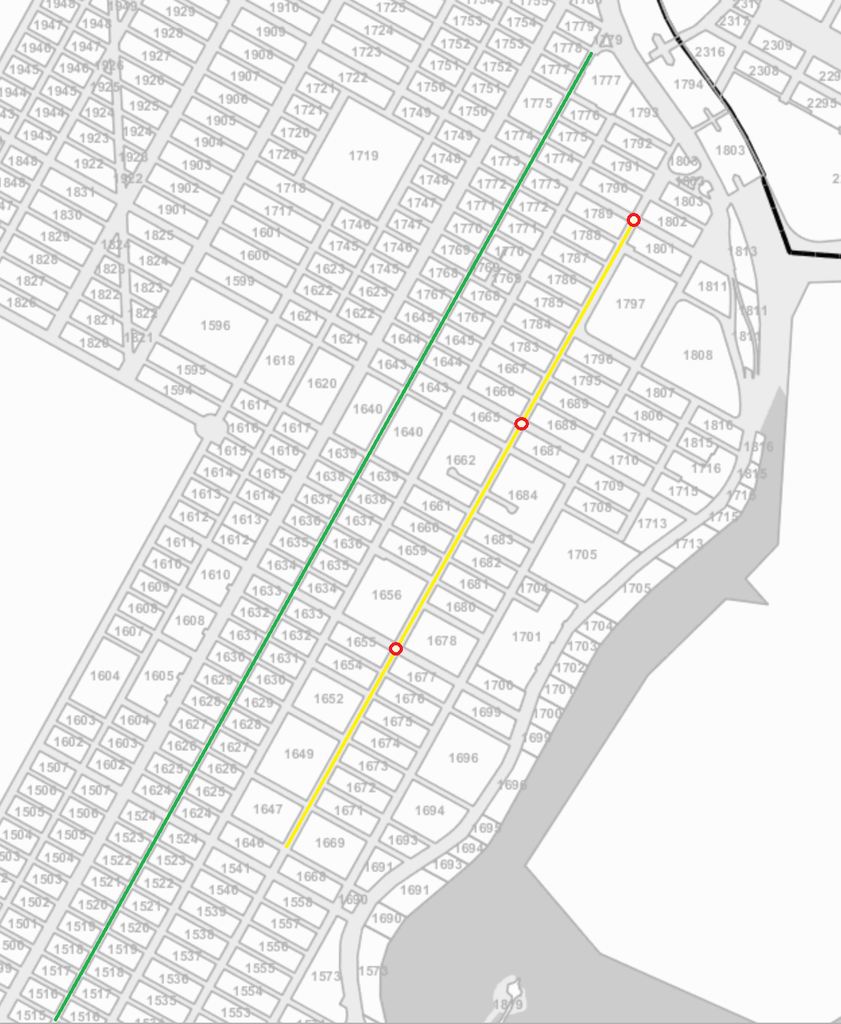

Using the map above, we determined the following 4 categories:

1. block numbers that are within 1 block to the left;
2. block numbers that are within 1 block to the right;
3. block numbers that are within 2-3 blocks to the left; and
4. block numbers that are within 2-3 blocks to the right; from the 2nd Ave Line

```r
property_upper_east <- read.csv("property_upper_east.csv")
data_phase2 <- property_upper_east %>%
  mutate(Distance = ifelse(BLOCK %in% c(1654:1656, 1665:1667, 1788:1791,1647:1652,1659:1662,
                                        1783:1787), '1 block left from phase 2 line',
                          ifelse(BLOCK %in% c(1676:1678, 1687:1689, 1801:1803,1669:1675,
                                            1680:1684,1795:1797),'1 block right from phase 2 line',
                          ifelse(BLOCK %in% c(1625:1640,1643:1645,1767:1776),
                                 '2-3 blocks left from phase 2 line',
                          ifelse(BLOCK %in% c(1691,1693:1696,1699:1705,1708:1711,1713,1715:1716,                                              1806:1808,1815,1816,1811,1813),
                                 '2-3 blocks right from phase 2 line',
                                 'other')))))
```

Now we can visualize and compare the variation of Property Market Values over time, among the different categories detailed above, by following the same procedure described previously:

```r
#First, summarize by Year and Distance:
data_phase2 <- data_phase2 %>%
  group_by(Year, Distance) %>%
  summarise(Total = sum(FULLVAL))
#head(data_phase1)

#Now, scale the data and create an index to visualize variations over time, then plot:
data_phase2 <- data_phase2 %>% group_by(Distance) %>%
  #filter(Year >= 2001 & Year <= 2017) %>%
  filter(Distance != "other") %>%
  mutate(index = 100*Total/Total[1]) %>% ungroup()
head(data_phase2)
```

```
## # A tibble: 6 x 4
##    Year Distance                                Total index
##   <int> <chr>                                   <dbl> <dbl>
## 1  2008 1 block left from phase 2 line      939224158 100
## 2  2008 1 block right from phase 2 line     921704001 100
## 3  2008 2-3 blocks left from phase 2 line  1241301403 100
## 4  2008 2-3 blocks right from phase 2 line  740555839 100
## 5  2009 1 block left from phase 2 line      780898205  83.1
## 6  2009 1 block right from phase 2 line     912708341  99.0
```

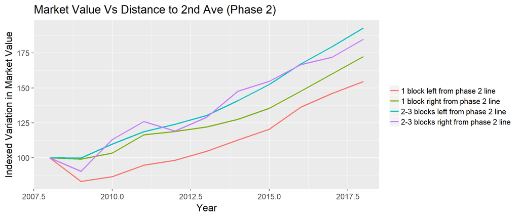

```r
#save results to be used for presentation purposes:
#write.table(data_phase1,file="Markt_Value-2nd-ave-line_phase1_left.csv",sep=",",row.names=F)

#Plot time series:
ggplot(data_phase2, aes(Year, index, color = Distance)) + geom_line(lwd = 1) +
    ggtitle("Market Value Vs Distance to 2nd Ave (Phase 2)") +
    labs (x = "Year", y = "Indexed Variation in Market Value") +
    theme_grey(16) +
    theme(legend.title = element_blank())
```

**Conclusions:** From the graph above we think that it is inconclusive whether the planned phase 2 of the 2nd Ave Line project is having an impact on the increase in Property Market Value for properties located in the vicinity of the Line. On the contrary, we can see that properties located within 2-3 blocks from the Line, show a slightly higher increase than properties located within 1 block from the Line.

So, as additional work, since we wanted to analyse years previous to the commencement of the construction of phase 1, We performed an additional research and were able to find property “Assessed Values”" back to 2003 in the “Primary Land Use Tax Lot Output” (PLUTO) dataset, developed by the New York City Department of City Planning’s (DCP) Information Technology Division (ITD), which is New York City’s primary land use agency.

Although the property “Market Values” are different from property “Assessed Values”, we found that they are linearly correlated since, according to the NY state DOF (https://www.tax.ny.gov/pit/property/learn/howassess.htm), the property “Assessed Value” is a percentage of the estimated “Market Value” of a property depending of the tax class so, as example, in a city or town assessing at 100% of market value for a specific tax class, the market value for that class is equal to the assessment value.

due to the extensive work needed to read and pre-process the data (one data file per year), the additional work performed is presented in separate RMD/Html files.